# Rysowanie zbioru Mandelbrota

Zamiemy się rysowaniem zbioru Mandelbrota i robieniem zbliżenia na jego wybrane fragmenty. Używam tutaj jądra SageMath aby korzystać z wielu ciekawych funkcji bez importowania ich z bibliotek.

Funkcja generująca siatkę na prostokącie [a,b]x[c,d]

dd - odległość między sąsiednimi punktami na siatce

```python
def mesh(dd): #funkcja tworząca siatkę na prostokącie [-2,1]x[1,1]
    M = []    # dd - odległość między punktami na siatce
    xp = floor(3/dd)
    yp = floor(2/dd)
    for i in range(1,xp):
        for j in range(1,yp):
            M += [ (-2+i*dd , -1 +j*dd )]
    return(M)
```

funkcja tworząca siatkę na prostokącie [a,b]x[c,d]

```python
def mesh2(dd, a, b, c, d): #funkcja tworząca siatkę na prostokącie [a,b]x[c,d]
    M = []
    xp = floor((b-a)/dd)
    yp = floor((d-c)/dd)
    for i in range(1,xp):
        for j in range(1,yp):
            M += [ (a+i*dd , c+j*dd )]
    return(M)
```

Rysowanie siatki

```python
def mesh_plot(d):
    M = mesh(d)
    return points(M)
```

Funkcja, którą będziemy składać aby określić, które punkty mają należeć do zbioru Mandelbrota, a które nie. Funkcja przyjmuje dwa wektory dwuwymiarowe, które reprezentują liczby zespolone oraz zwraca wektor dwuwymiarowy reprezentujący liczbę zespoloną.

```python
def g(z, c):
    return ( z[0]**2-z[1]**2+c[0], 2*z[0]*z[1]+c[1]  )
```

n-krotne złożenie funkcji g

```python
def gn(z,c,n):
    new = g(z,c)
    for i in range(n-1):
        new = g(new,c)
    return(new)
```

```python
gn((0,0),(1/2,1/2),7)
```

```
(14893924641/4294967296, 23823384307/134217728)
```

Norma, czy też moduł liczby zespolonej z.

```python
def norm(z):
    return ((z[0]^2+z[1]^2)^(1/2)).n()
```

Funkcja f przyjmuje za argumenty siatkę M oraz liczbę n oznaczającą liczbę złożeń ze sobą funkcji g. Do zbioru Mandelbrota należą wszystkie te liczby zespolone ${\tt point}$, dla których ciąg ${\tt gn((0,0), point, n )}$ nie zbiega do nieskończoności. Poniższa funkcja bierze wszystkie punkty z siatki*, oblicza n-krotne złożenie funkcji g i sprawdza, czy moduł tak otrzymanej liczby zespolonej jest mniejszy od 2.

Dlaczego od 2? Ponieważ jeśli moduł którejś z liczb z ciągu iteracji byłby większy od 2, taki ciąg szybko dążyłby do nieskończoności. Jeśli moduł jest mnieszy od 2, to wszystko wskazuje na to, że taki ciąg nie ucieka do nieskończoności.

Po wykonaniu sprawdzenia tworzona jest nowa siatka, w której przy punkcie umieszczana jest informacja czy punkt należy do zbioru Mandelbrota (1) czy nie (0).

* Tworząc lepszy algorytm wcale nie trzeba sprawdzać wszystkich punktów z siatki, bo to co ciekawe dzieje się jedynie na brzegu zbioru Mandelbrota. Jednak na potrzeby tego, żeby tylko zobaczyć zbiór Mandelbrota lub jego niewielkie przybliżenia zostaniemy przy obecnej wersji.

```python
def f(M, n):
    N = []
    for point in M:
        if norm(gn((0,0), point, n )) < 2:
            N += [[point, 1]]
        else:
            N += [[point, 0]]
    return(N)
```

Funkcja draw pracuje z siatką na prostokącie [-2,1]x[1,1], aby na grafice widać było zbiór Mandelbrota w całości. W funkcji następuje sprawdzenie, które punkty z siatki należą do zbioru Mandelbrota, a które nie, a następnie rysowana jest grafika - punkty należące do zbioru Mandelbrota rysowane są jako większe, a nienależące do niego jako mniejsze.

Zmienna ${\tt sizee}$ odpowiada za wielkość punktów należących do zbioru Mandelbrota na wykresie, a ${\tt size_\_how_\_much}$ odpowiada za wielkość punktów do niego nienależących.

Im większe ${\tt sizee}$, tym większe kropki należące do zbioru.

Im mniejsze ${\tt size_\_how_\_much}$ tym mniej zmniejszamy kropki nienależące do zbioru, czyli robią się one większe.

```python
def draw(d, n, sizee, size_how_much):
    N = f(mesh(d), n)
    inMandel = [pointex[0] for pointex in N if pointex[1] == 1]
    outMandel = [pointex[0] for pointex in N if pointex[1] == 0]
    return (points(inMandel, size = sizee) + points(outMandel, size = sizee/size_how_much))
```

Funkcja draw2 robi to samo, ale na siatce dowolnych rozmiarów (w domyśle na mniejszym prostokącie, bo za pomocą tej funkcji będziemy przyglądać się zbiorowi Mandelbrota w większym przybliżeniu).

```python
def draw2(dd, a, b, c, d, n, sizee, size_how_much, aspect_ratioo = True):
    N = f(mesh2(dd, a, b, c, d), n)
    inMandel = [pointex[0] for pointex in N if pointex[1] == 1]
    outMandel = [pointex[0] for pointex in N if pointex[1] == 0]

    if aspect_ratioo == True:
        return (points(inMandel, size = sizee, aspect_ratio = 1) + points(outMandel, size = sizee/size_how_much, aspect_ratio = 1))
    else:
        return (points(inMandel, size = sizee) + points(outMandel, size = sizee/size_how_much))
```

Narysujmy nareszcie zbiór Mandelbrota korzystając z funkcji draw.

[figure not shown]

```python
image = draw(0.02, 50, 10, 10)
image.show()
```

Wykonajmy pierwsze przybliżenie.

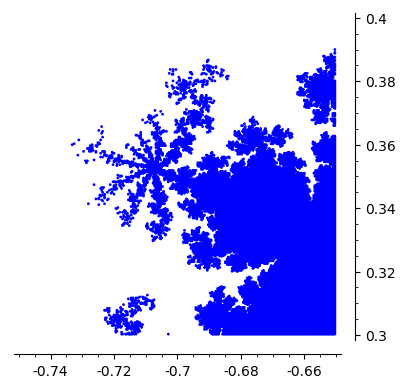

```python
draw2(0.0003, -0.75, -0.65, 0.3, 0.4, 65, 4, 10)
```

Zróbmy zoom na miejsce łączenia się "głowy żuka z jego tułowiem"

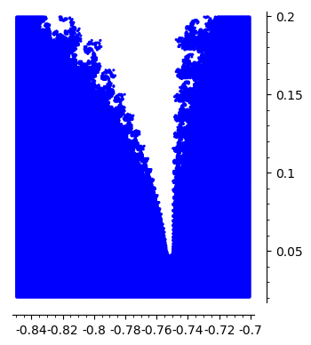

```python
draw2(0.0005, -0.85, -0.7, 0.02, 0.2, 65, 5, 10)
```

Popatrzmy jeszcze na kilka zbliżeń różnych części zbioru.

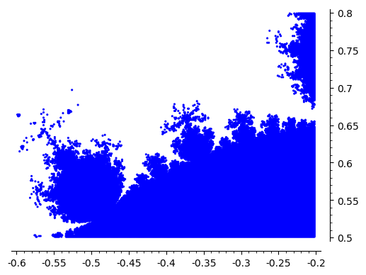

```python
draw2(0.001, -0.6, -0.2, 0.5, 0.8, 65, 5, 10)
```

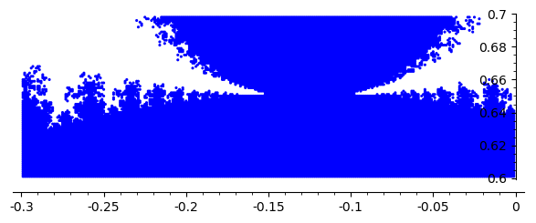

```python
draw2(0.001, -0.3, 0, 0.6, 0.7, 65, 5, 10)
```

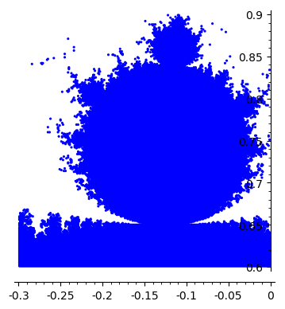

```python
draw2(0.001, -0.3, 0, 0.6, 0.9, 65, 5, 10)
```

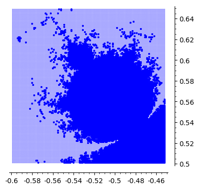

```python
draw2(0.001, -0.6, -0.45, 0.5, 0.65, 70, 8, 8)
```